# Texas Under-18 Population Growth

This script uses R’s tidycensus library to download county population data to reveal trends in the under-18 population, by ethnicity, from 2010 to 2017. Texas was a leader in under-18 population growth during that time. We also look at growth projections from the Texas Demographic Center, predicting those growth trends to continue for the foreseeable future.

```r
library(tidyverse)
library(tidycensus)
options(tigris_use_cache = TRUE)
```

## Under-18 population growth in Texas and other states, 2010-2017

First, compare counties in the six biggest states to see how Texas counties stack up in under-18 population growth.

```r
big10 <- get_acs("county", variables="B09001_001", year = 2010, output="tidy", state=c("Texas","California","New York","Illinois","Pennsylvania","Florida"), geometry=FALSE)
big17 <- get_acs("county", variables="B09001_001", year = 2017, output="tidy", state=c("Texas","California","New York","Illinois","Pennsylvania","Florida"), geometry=FALSE)
big10 <- big10 %>% rename('e10' = 'estimate') %>% select(c(-variable, -moe))
big17 <- big17 %>% rename('e17' = 'estimate') %>% select(c(-variable, -moe))
big <- inner_join(big10, big17, by="NAME")
big <- mutate(big, diff = e17 - e10)
big <- mutate(big, pct = (e17 / e10) - 1)
big <- arrange(big, desc(diff))
```

Top counties in under-18 population growth 2010-2017 among the six largest states.

| GEOID.x | NAME | e10 | GEOID.y | e17 | diff | pct |
| --- | --- | --- | --- | --- | --- | --- |
| 48201 | Harris County, Texas | 1116043 | 48201 | 1225059 | 109016 | 0.0976808 |
| 48439 | Tarrant County, Texas | 489908 | 48439 | 534079 | 44171 | 0.0901618 |
| 48029 | Bexar County, Texas | 449711 | 48029 | 493218 | 43507 | 0.0967444 |
| 48113 | Dallas County, Texas | 643888 | 48113 | 682882 | 38994 | 0.0605602 |
| 48157 | Fort Bend County, Texas | 162373 | 48157 | 198856 | 36483 | 0.2246864 |
| 48085 | Collin County, Texas | 212857 | 48085 | 245804 | 32947 | 0.1547847 |
| 48453 | Travis County, Texas | 234411 | 48453 | 267205 | 32794 | 0.1398996 |
| 48121 | Denton County, Texas | 174237 | 48121 | 201209 | 26972 | 0.1548006 |
| 48215 | Hidalgo County, Texas | 257195 | 48215 | 281529 | 24334 | 0.0946130 |
| 12095 | Orange County, Florida | 268371 | 12095 | 291909 | 23538 | 0.0877069 |
| 48339 | Montgomery County, Texas | 119483 | 48339 | 142639 | 23156 | 0.1938016 |
| 48491 | Williamson County, Texas | 113286 | 48491 | 135912 | 22626 | 0.1997246 |
| 12057 | Hillsborough County, Florida | 292405 | 12057 | 311707 | 19302 | 0.0660112 |
| 06085 | Santa Clara County, California | 421580 | 06085 | 435016 | 13436 | 0.0318706 |
| 36081 | Queens County, New York | 460988 | 36081 | 473695 | 12707 | 0.0275647 |
| 12097 | Osceola County, Florida | 68872 | 12097 | 81408 | 12536 | 0.1820188 |
| 36047 | Kings County, New York | 596320 | 36047 | 608815 | 12495 | 0.0209535 |
| 12011 | Broward County, Florida | 395063 | 12011 | 406640 | 11577 | 0.0293042 |
| 12099 | Palm Beach County, Florida | 267882 | 12099 | 278119 | 10237 | 0.0382146 |
| 48209 | Hays County, Texas | 35652 | 48209 | 45695 | 10043 | 0.2816953 |

Just counties in Texas.

```r
texas_under18 <- filter(big, str_detect(NAME, 'Texas')) %>% arrange(desc(diff))
texas_under18[1:20,]
```

```
## # A tibble: 20 x 7
##    GEOID.x NAME                         e10 GEOID.y     e17   diff    pct
##    <chr>   <chr>                      <dbl> <chr>     <dbl>  <dbl>  <dbl>
##  1 48201   Harris County, Texas     1116043 48201   1225059 109016 0.0977
##  2 48439   Tarrant County, Texas     489908 48439    534079  44171 0.0902
##  3 48029   Bexar County, Texas       449711 48029    493218  43507 0.0967
##  4 48113   Dallas County, Texas      643888 48113    682882  38994 0.0606
##  5 48157   Fort Bend County, Texas   162373 48157    198856  36483 0.225
##  6 48085   Collin County, Texas      212857 48085    245804  32947 0.155
##  7 48453   Travis County, Texas      234411 48453    267205  32794 0.140
##  8 48121   Denton County, Texas      174237 48121    201209  26972 0.155
##  9 48215   Hidalgo County, Texas     257195 48215    281529  24334 0.0946
## 10 48339   Montgomery County, Texas  119483 48339    142639  23156 0.194
## 11 48491   Williamson County, Texas  113286 48491    135912  22626 0.200
## 12 48209   Hays County, Texas         35652 48209     45695  10043 0.282
## 13 48027   Bell County, Texas         83569 48027     93524   9955 0.119
## 14 48039   Brazoria County, Texas     83635 48039     92813   9178 0.110
## 15 48329   Midland County, Texas      36510 48329     44653   8143 0.223
## 16 48135   Ector County, Texas        38722 48135     46627   7905 0.204
## 17 48303   Lubbock County, Texas      65177 48303     71931   6754 0.104
## 18 48041   Brazos County, Texas       37759 48041     44230   6471 0.171
## 19 48479   Webb County, Texas         85595 48479     91379   5784 0.0676
## 20 48167   Galveston County, Texas    73475 48167     79083   5608 0.0763
```

And counties in all states.

```r
all10 <- get_acs("county", variables="B09001_001", year = 2010, output="tidy", geometry=FALSE)
all17 <- get_acs("county", variables="B09001_001", year = 2017, output="tidy", geometry=FALSE)
all10 <- all10 %>% rename('e10' = 'estimate') %>% select(c(-variable, -moe))
all17 <- all17 %>% rename('e17' = 'estimate') %>% select(c(-variable, -moe))
all <- inner_join(all10, all17, by="NAME")
all <- mutate(all, diff = e17 - e10)
all <- arrange(all, desc(diff))
all[1:20,]
```

```
## # A tibble: 20 x 6
##    GEOID.x NAME                                   e10 GEOID.y    e17   diff
##    <chr>   <chr>                                <dbl> <chr>    <dbl>  <dbl>
##  1 48201   Harris County, Texas               1116043 48201   1.23e6 109016
##  2 48439   Tarrant County, Texas               489908 48439   5.34e5  44171
##  3 48029   Bexar County, Texas                 449711 48029   4.93e5  43507
##  4 48113   Dallas County, Texas                643888 48113   6.83e5  38994
##  5 48157   Fort Bend County, Texas             162373 48157   1.99e5  36483
##  6 53033   King County, Washington             404906 53033   4.39e5  34162
##  7 48085   Collin County, Texas                212857 48085   2.46e5  32947
##  8 48453   Travis County, Texas                234411 48453   2.67e5  32794
##  9 37183   Wake County, North Carolina         222260 37183   2.53e5  30430
## 10 49049   Utah County, Utah                   168868 49049   1.99e5  30155
## 11 48121   Denton County, Texas                174237 48121   2.01e5  26972
## 12 04013   Maricopa County, Arizona           1004490 04013   1.03e6  26375
## 13 37119   Mecklenburg County, North Carolina  225504 37119   2.52e5  26246
## 14 48215   Hidalgo County, Texas               257195 48215   2.82e5  24334
## 15 12095   Orange County, Florida              268371 12095   2.92e5  23538
## 16 48339   Montgomery County, Texas            119483 48339   1.43e5  23156
## 17 48491   Williamson County, Texas            113286 48491   1.36e5  22626
## 18 40109   Oklahoma County, Oklahoma           177006 40109   1.99e5  21775
## 19 32003   Clark County, Nevada                479592 32003   5.00e5  20158
## 20 51107   Loudoun County, Virginia             88997 51107   1.09e5  19766
```

## Mobility of the under-18 population

Next we look at mobility/migration from other states and other countries, using summaries of B07001_002 (ages 0-4) and 003 (ages 5-17), and variables 066 and 067 (moved from different state) and 082 and 083 (moved from abroad). The goal is to produce a table with each county and fields for total 0-17, # migrated from other state, and number migrated from another country. This can be adapted to compare all counties in all states simply by removing the “state” parameter from the get_acs() call.

```r
migr17 <- get_acs("county", variables = c("B07001_002", "B07001_003", "B07001_066", "B07001_082", "B07001_067", "B07001_083"), year = 2017, output = "tidy", state = 48, geometry = FALSE)
migr17 <- migr17 %>% select(-moe) %>% spread(variable, estimate)
migr17 <- migr17 %>% mutate(total_kids = B07001_002 + B07001_003)
migr17 <- migr17 %>% mutate(another_state = B07001_066 + B07001_067)
migr17 <- migr17 %>% mutate(another_country = B07001_082 + B07001_083)
migr17 <- migr17 %>% select(-starts_with('B07'))
migr17 <- migr17 %>% mutate(pct_state = another_state / total_kids)
migr17 <- migr17 %>% mutate(pct_country = another_country / total_kids)
migr17 <- migr17 %>% mutate(total_migrants = another_state + another_country)
migr17 <- migr17 %>% mutate(pct_migrants = total_migrants / total_kids)
migr17 <- migr17 %>% arrange(desc(total_migrants))
migr17[1:20,]
```

```
## # A tibble: 20 x 9
##    GEOID NAME  total_kids another_state another_country pct_state
##    <chr> <chr>      <dbl>         <dbl>           <dbl>     <dbl>
##  1 48201 Harr…    1157942         17200           13712   0.0149
##  2 48439 Tarr…     505500         10714            3324   0.0212
##  3 48029 Bexa…     465967          9559            3382   0.0205
##  4 48113 Dall…     646568          7337            5019   0.0113
##  5 48141 El P…     221407          6161            3127   0.0278
##  6 48085 Coll…     234737          6507            2036   0.0277
##  7 48027 Bell…      87767          6050             643   0.0689
##  8 48157 Fort…     191012          3601            3077   0.0189
##  9 48121 Dent…     191865          5047            1432   0.0263
## 10 48453 Trav…     252442          4367            1837   0.0173
## 11 48339 Mont…     135282          3553            1111   0.0263
## 12 48491 Will…     129257          3315             655   0.0256
## 13 48215 Hida…     267912          1083            1591   0.00404
## 14 48355 Nuec…      84870          1520             309   0.0179
## 15 48039 Braz…      88241          1592              73   0.0180
## 16 48167 Galv…      74968          1290             367   0.0172
## 17 48187 Guad…      37766          1499             149   0.0397
## 18 48099 Cory…      17291          1376             201   0.0796
## 19 48061 Came…     125912           467             981   0.00371
## 20 48329 Midl…      41713          1167             121   0.0280
## # … with 3 more variables: pct_country <dbl>, total_migrants <dbl>,
## #   pct_migrants <dbl>
```

## Texas Demographic Center projections of under-18 population, 2020-2050

Next we map the [Texas Demographic Center](https://demographics.texas.gov/Data/TPEPP/Projections/)’s projected differences by county and ethnicity between 2020 and 2050.

First we get the map geometry from ACS. Then we read in an Excel sheet, prepared from the projections provided on the TDC web site, and merge with the county geography. Finally we cycle through a series of maps to show where growth is expected, by raw numbers and percentages.

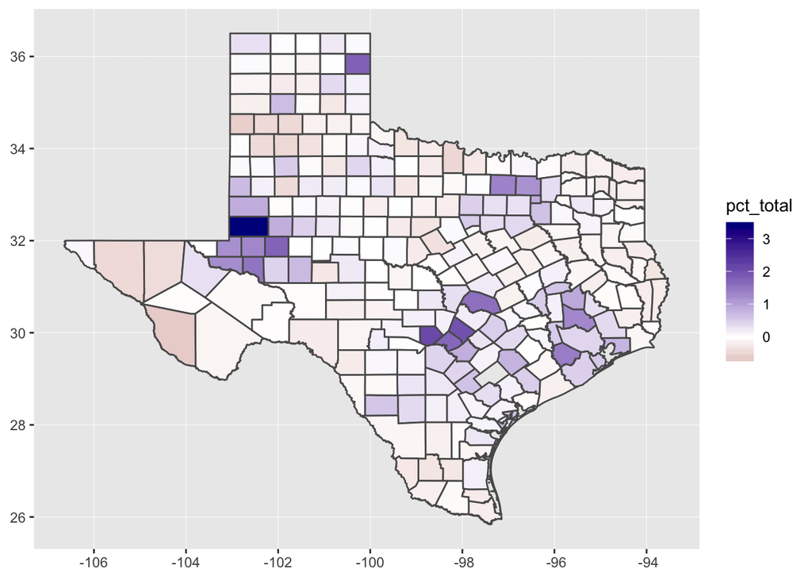

```r
under18 <- get_acs(state = "TX", geography = "county", variables = "B09001_001", geometry = TRUE, year = 2017)
under18$NAME <- sub(", Texas", "", under18$NAME)
library(readxl)
X2018allcntyagegrp <- read_excel("tdc_projections.xlsx", sheet = "diffs and pcts only")
counties <- inner_join(X2018allcntyagegrp, under18, by = c("Row Labels" = "NAME"))

ggplot(data = counties, aes(fill = pct_total)) + geom_sf() + scale_fill_gradient2(high = "dark blue")
```

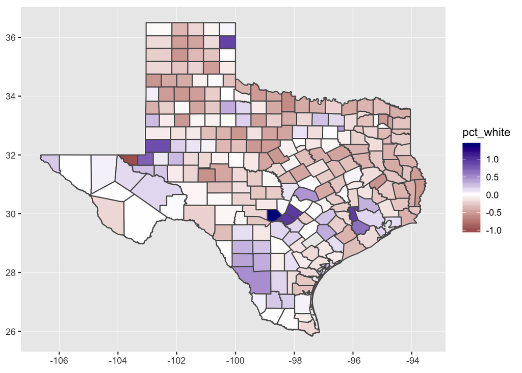

```r
ggplot(data = counties, aes(fill = pct_white)) + geom_sf() + scale_fill_gradient2(high = "dark blue")
```

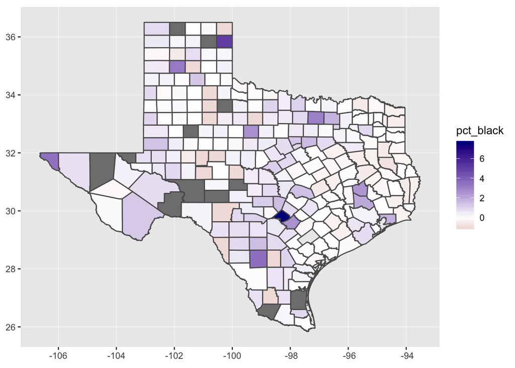

```r
ggplot(data = counties, aes(fill = pct_black)) + geom_sf() + scale_fill_gradient2(high = "dark blue")
```

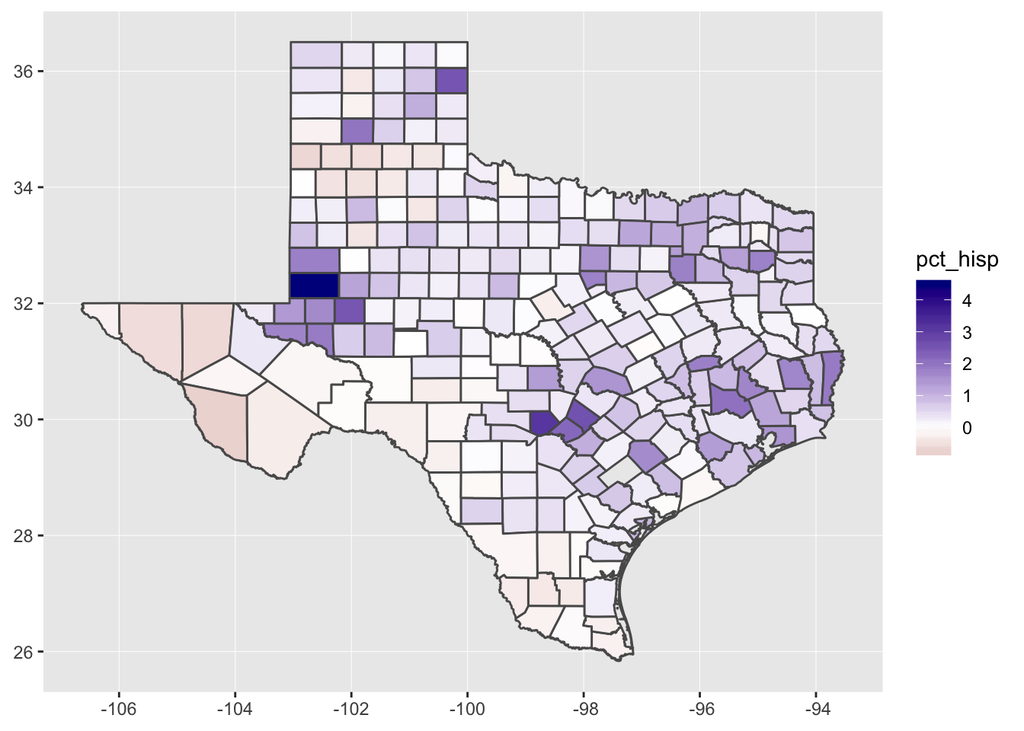

```r
ggplot(data = counties, aes(fill = pct_hisp)) + geom_sf() + scale_fill_gradient2(high = "dark blue")
```

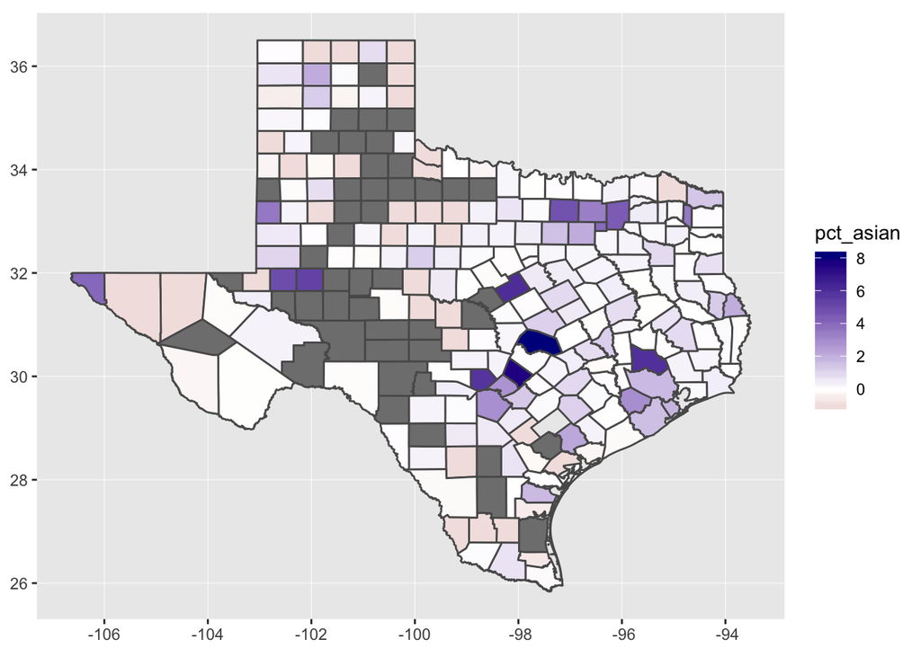

```r
ggplot(data = counties, aes(fill = pct_asian)) + geom_sf() + scale_fill_gradient2(high = "dark blue")
```

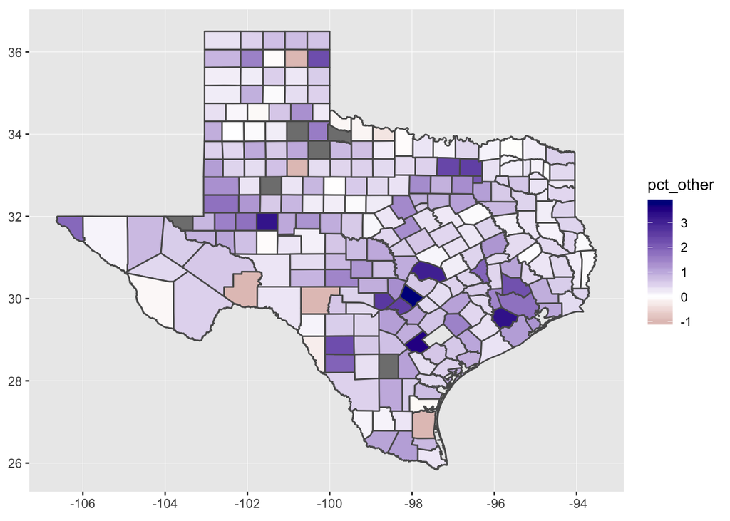

```r
ggplot(data = counties, aes(fill = pct_other)) + geom_sf() + scale_fill_gradient2(high = "dark blue")
```

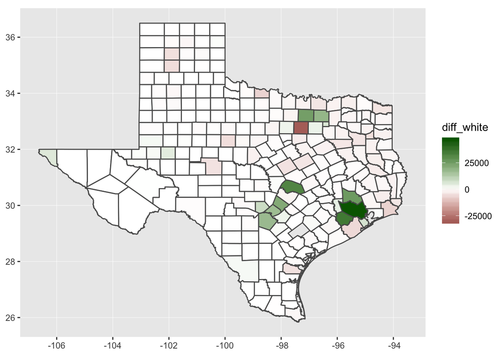

```r
ggplot(data = counties, aes(fill = diff_white)) + geom_sf() + scale_fill_gradient2(high = "dark green")
```

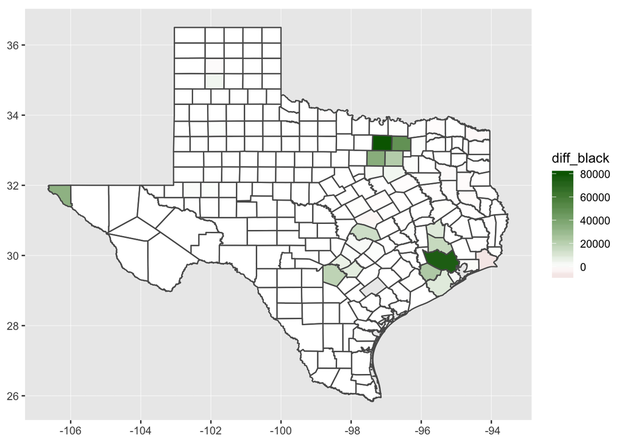

```r
ggplot(data = counties, aes(fill = diff_black)) + geom_sf() + scale_fill_gradient2(high = "dark green")
```

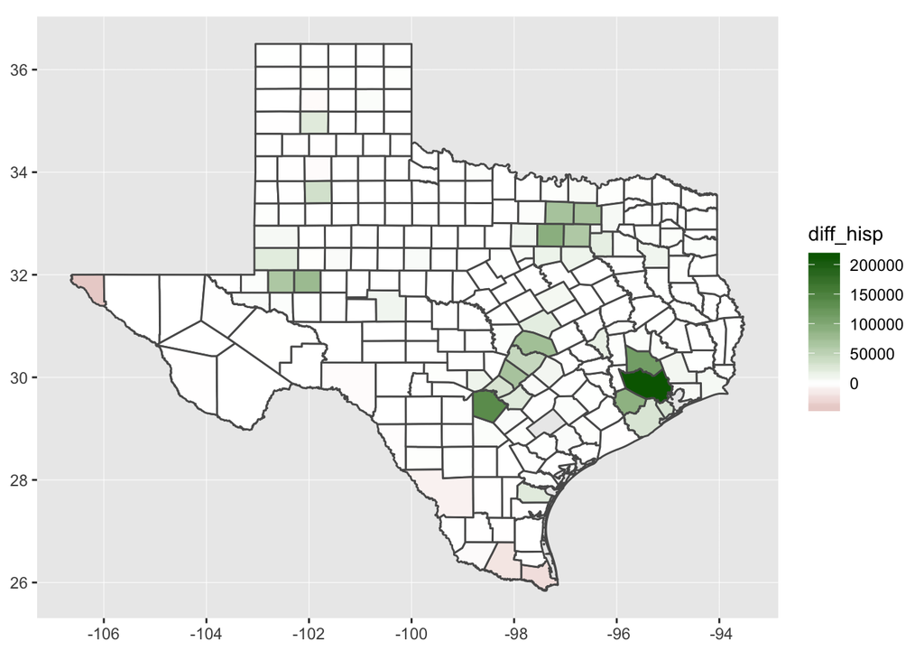

```r
ggplot(data = counties, aes(fill = diff_hisp)) + geom_sf() + scale_fill_gradient2(high = "dark green")
```

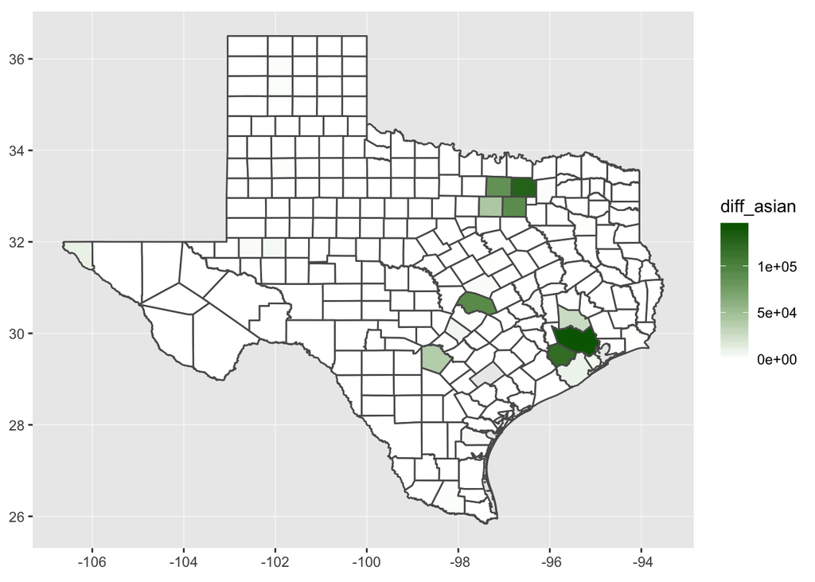

```r
ggplot(data = counties, aes(fill = diff_asian)) + geom_sf() + scale_fill_gradient2(high = "dark green")
```

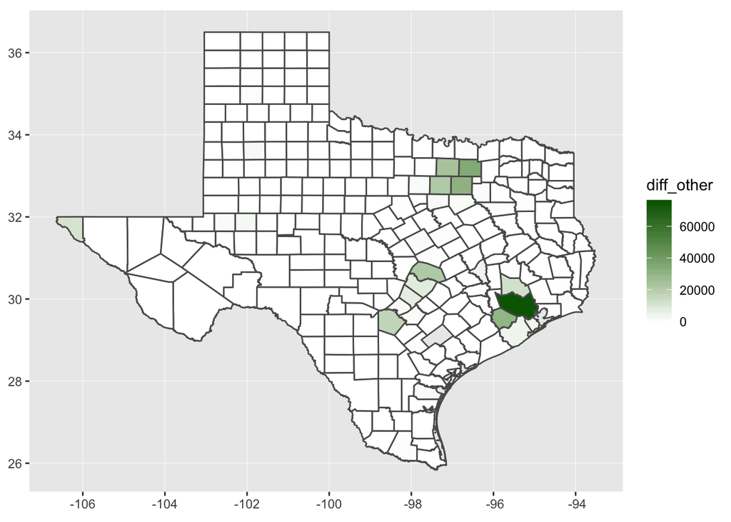

```r
ggplot(data = counties, aes(fill = diff_other)) + geom_sf() + scale_fill_gradient2(high = "dark green")
```